# Preregistered Analysis FamVoice ACQ

2024-03-08

### Simulate some data

```r
source(here("code/R","01_data_simulation.R"), local = knitr::knit_global())
```

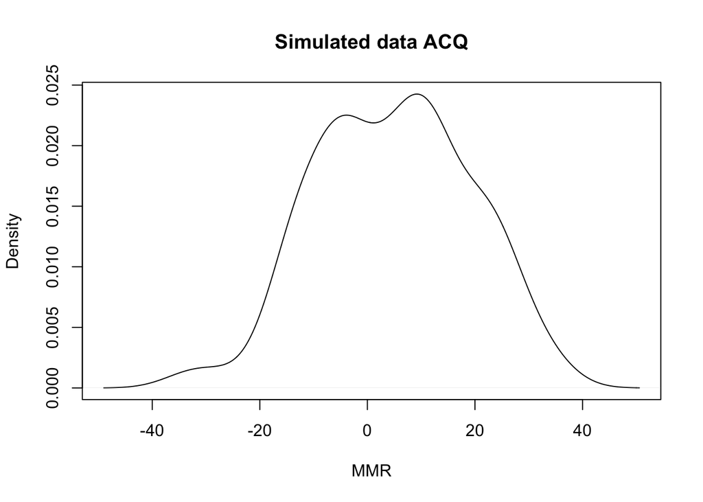

```r
head(dat_acq)
```

```
## # A tibble: 6 × 8
##   Subj   Group TestSpeaker    MMR mumDist nrSpeakersDaily sleepState     age
##   <fct>  <fct> <fct>        <dbl>   <dbl>           <dbl> <fct>        <dbl>
## 1 Subj01 fam   1           -13.9   -1.27            0.229 activesleep 0.884
## 2 Subj01 fam   2            -2.06   1.16            0.229 quietsleep  0.884
## 3 Subj02 fam   1            -2.81   1.67           -1.46  activesleep 0.165
## 4 Subj02 fam   2           -18.8    0.550          -1.46  quietsleep  0.165
## 5 Subj03 fam   1             9.52  -1.23           -0.335 activesleep 0.0626
## 6 Subj03 fam   2            -8.66  -1.10           -0.335 quietsleep  0.0626
```

```r
summary(dat_acq)
```

```
##       Subj       Group    TestSpeaker      MMR             mumDist
##  Subj01 :  2   fam  :64   1:64        Min.   :-34.385   Min.   :-1.2665
##  Subj02 :  2   unfam:64   2:64        1st Qu.: -5.480   1st Qu.:-0.8524
##  Subj03 :  2                          Median :  5.243   Median :-0.1942
##  Subj04 :  2                          Mean   :  4.832   Mean   : 0.0000
##  Subj05 :  2                          3rd Qu.: 14.010   3rd Qu.: 0.8062
##  Subj06 :  2                          Max.   : 35.945   Max.   : 3.2230
##  (Other):116
##  nrSpeakersDaily         sleepState      age
##  Min.   :-1.4636   activesleep:47   Min.   :-2.29938
##  1st Qu.:-0.8993   awake      :36   1st Qu.:-0.86166
##  Median : 0.2292   quietsleep :45   Median : 0.06258
##  Mean   : 0.0000                    Mean   : 0.00000
##  3rd Qu.: 0.3703                    3rd Qu.: 0.67874
##  Max.   : 3.0506                    Max.   : 1.91107
##
```

### Set priors based on pilot data

Load the pilot data

```r
#source(here("code/R","02_choose_priors.R"), local = knitr::knit_global())   This does not work takes too long to knit.. save models in R script
# load pilot data --------------------------------------------------------------------
data_pilot = read_csv(here("data","data_pilot.csv"))
data_pilot$TestSpeaker = as.factor(data_pilot$TestSpeaker)
```

Now we have a look at the pilot data:

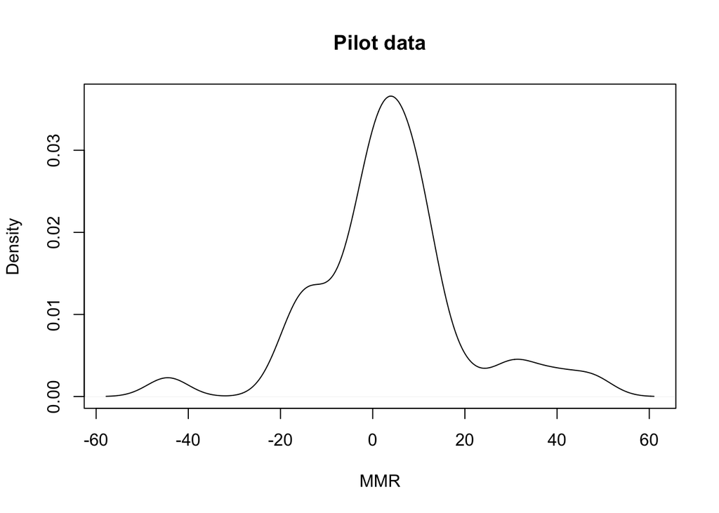

```r
plot(density(data_pilot$MMR),
     main="Pilot data",xlab="MMR")
```

```r
mean(data_pilot$MMR)
```

```
## [1] 3.546836
```

```r
sd(data_pilot$MMR)
```

```
## [1] 16.40196
```

We see that the data are normally distributed, with mean = 3.546836, SD = 16.40196

This means that we will choose a Gaussian function as the likelihood function for all models. We will check with our experimental data whether they are also normally distributed. If not, we will adapt the likelihood function accordingly.

Now we run a model with weakly informative priors

```r
prior_pilot <-
  c(
    prior("normal(0, 35)", class = "Intercept"), #  weakly informative prior on intercept
    prior("normal(0, 35)", class = "b") #  weakly informative prior on slope
  )

# pilot_m = brm(MMR ~ 1 + TestSpeaker + (1 | Subj),
#                prior = prior_pilot,
#                data = data_pilot,
#                control = list(
#                  adapt_delta = .99,
#                  max_treedepth = 15),
#                file = here("data", "model_output", "02_pilot.rds")
#                )

pilot_m <- readRDS(here("data", "model_output", "02_pilot.rds"))
summary(pilot_m)
```

```
##  Family: gaussian
##   Links: mu = identity; sigma = identity
## Formula: MMR ~ 1 + TestSpeaker + (1 | Subj)
##    Data: data_pilot (Number of observations: 39)
##   Draws: 4 chains, each with iter = 2000; warmup = 1000; thin = 1;
##          total post-warmup draws = 4000
##
## Group-Level Effects:
## ~Subj (Number of levels: 13)
##               Estimate Est.Error l-95% CI u-95% CI Rhat Bulk_ESS Tail_ESS
## sd(Intercept)     5.42      3.42     0.32    12.94 1.00     1361     2054
##
## Population-Level Effects:
##              Estimate Est.Error l-95% CI u-95% CI Rhat Bulk_ESS Tail_ESS
## Intercept        3.53      3.15    -2.64     9.92 1.00     3088     2731
## TestSpeaker1     0.38      3.74    -6.97     7.68 1.00     4054     2997
## TestSpeaker2    -1.55      3.74    -9.03     5.83 1.00     4107     2394
##
## Family Specific Parameters:
##       Estimate Est.Error l-95% CI u-95% CI Rhat Bulk_ESS Tail_ESS
## sigma    16.12      2.08    12.52    20.63 1.00     2712     2707
##
## Draws were sampled using sampling(NUTS). For each parameter, Bulk_ESS
## and Tail_ESS are effective sample size measures, and Rhat is the potential
## scale reduction factor on split chains (at convergence, Rhat = 1).
```

This model estimates a mean of 3.53, and a sigma of 16.12.

We base our priors on this:

- mean = 3.5
- sigma = 20 (We add some uncertainly, so we multiply sigma by 1.25)

giving us:

```r
priors <- c(set_prior("normal(3.5, 20)",  # sd=20 is here the SD of the distribution of the prior on mu, so how uncertain we are about the value of mu
                      class = "Intercept"),
            set_prior("normal(0, 20)",  # this is the prior on the slope
                      class = "b"),
            set_prior("normal(0, 20)",  # this is our expectation about the error in the model, so the residual noise. it's the SD of the likelihood. It's the SD of the MMR in this case sigma represents the standard deviation of the response variable, mmr in this case
                      class = "sigma")) # brms will automatically truncate the prior specification for σ and allow only positive values (https://vasishth.github.io/bayescogsci/book/ch-reg.html), so we don't have to truncate the distribution ourselves
```

Let’s visualize the priors

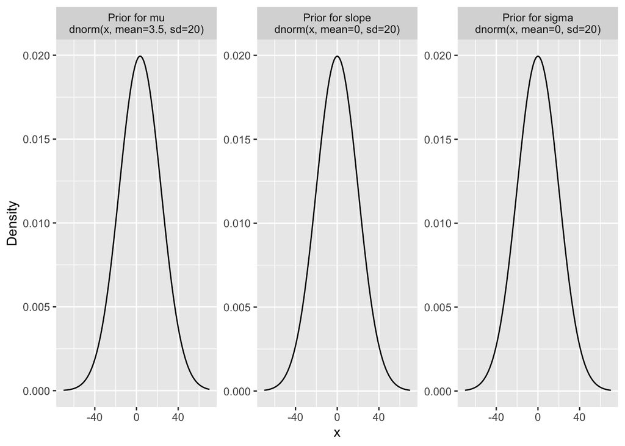

```r
# Visualize the priors
dpri <- data.frame(x = seq(-70,70,by=1))
dpri$y1 <- dnorm(dpri$x,mean=3.5,sd=20)
dpri$y2 <- dnorm(dpri$x,mean=0,sd=20)
dpri$y3 <- dnorm(dpri$x,mean=0,sd=20)

dprig <- dpri %>% gather(y1, y2, y3, key="Prior", value="Density")
dprig$Prior <- factor(dprig$Prior)
levels(dprig$Prior) <- c("Prior for mu\ndnorm(x, mean=3.5, sd=20)", "Prior for slope\ndnorm(x, mean=0, sd=20)", "Prior for sigma\ndnorm(x, mean=0, sd=20)")
ggplot(data=dprig, aes(x=x, y=Density)) + geom_line() + facet_wrap(~Prior, scales="free")
```

### Prior predictive checks

Here, we check what happens if run the model based on our priors only.

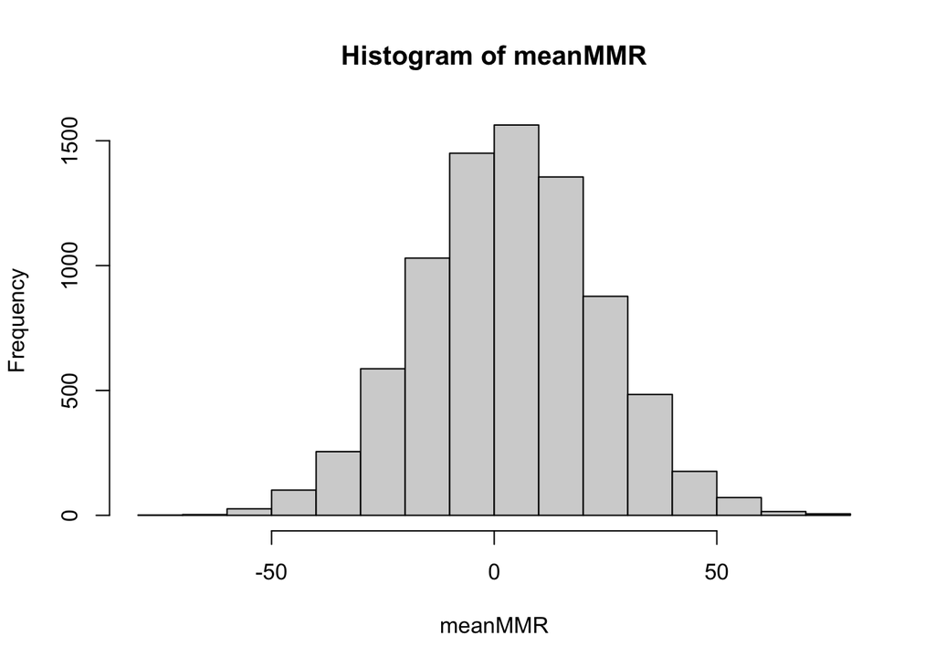

```r
# num_chains <- 4
# num_iter <- 4000
# num_warmup <- num_iter / 2
# num_thin <- 1

# priorpredcheck_acq_m <- brm(MMR ~ 1 + TestSpeaker * Group +
#                               mumDist +
#                               nrSpeakersDaily  +
#                               sleepState +
#                               age +
#                               (1 + TestSpeaker | Subj),
#                             data = dat_acq,
#                             prior = priors,
#                             family = gaussian(),
#                             control = list(
#                               adapt_delta = .99,
#                               max_treedepth = 15
#                             ),
#                             iter = num_iter,
#                             chains = num_chains,
#                             warmup = num_warmup,
#                             thin = num_thin,
#                             cores = num_chains,
#                             seed = project_seed,
#                             file = here("data", "model_output", "03_model_priorpredcheck_acq.rds"),
#                             file_refit = "on_change",
#                             save_pars = save_pars(all = TRUE),
#                             sample_prior = "only"
# )

priorpredcheck_acq_m <- readRDS(here("data", "model_output", "03_model_priorpredcheck_acq.rds"))

pp <- posterior_predict(priorpredcheck_acq_m)
pp <- t(pp)
# distribution of mean MMR
meanMMR = colMeans(pp)
hist(meanMMR, breaks = 20)
```

```r
summary(priorpredcheck_acq_m)
```

```
##  Family: gaussian
##   Links: mu = identity; sigma = identity
## Formula: MMR ~ 1 + TestSpeaker * Group + mumDist + nrSpeakersDaily + sleepState + age + (1 + TestSpeaker | Subj)
##    Data: dat_acq (Number of observations: 128)
##   Draws: 4 chains, each with iter = 4000; warmup = 2000; thin = 1;
##          total post-warmup draws = 8000
##
## Group-Level Effects:
## ~Subj (Number of levels: 64)
##                             Estimate Est.Error l-95% CI u-95% CI Rhat Bulk_ESS
## sd(Intercept)                  15.63     20.02     0.47    59.29 1.00    10534
## sd(TestSpeaker1)               15.40     18.44     0.51    58.74 1.00     9955
## cor(Intercept,TestSpeaker1)     0.01      0.57    -0.95     0.95 1.00    12808
##                             Tail_ESS
## sd(Intercept)                   3804
## sd(TestSpeaker1)                3839
## cor(Intercept,TestSpeaker1)     4641
##
## Population-Level Effects:
##                     Estimate Est.Error l-95% CI u-95% CI Rhat Bulk_ESS Tail_ESS
## Intercept               3.49     22.16   -39.63    47.27 1.00    12549     6078
## TestSpeaker1           -0.24     19.89   -38.83    38.60 1.00    12973     6274
## Group1                  0.12     19.82   -38.57    39.25 1.00    15118     5271
## mumDist                 0.18     20.06   -39.82    39.53 1.00    15067     5252
## nrSpeakersDaily        -0.33     20.10   -40.07    38.63 1.00    14990     5487
## sleepState1             0.13     19.68   -38.16    38.65 1.00    14243     5658
## sleepState2            -0.12     20.10   -39.92    38.83 1.00    14374     5737
## age                     0.34     20.35   -40.09    39.76 1.00    13419     5733
## TestSpeaker1:Group1     0.07     20.06   -39.00    38.75 1.00    13978     5721
##
## Family Specific Parameters:
##       Estimate Est.Error l-95% CI u-95% CI Rhat Bulk_ESS Tail_ESS
## sigma    16.00     12.31     0.57    45.66 1.00     6012     2939
##
## Draws were sampled using sampling(NUTS). For each parameter, Bulk_ESS
## and Tail_ESS are effective sample size measures, and Rhat is the potential
## scale reduction factor on split chains (at convergence, Rhat = 1).
```

In our priors, we specified a mean of 3.5 and an SD of 20. In these plots and the model summary, we see that the mean of the MMR is estimated at 3.49, and the SD at 16.

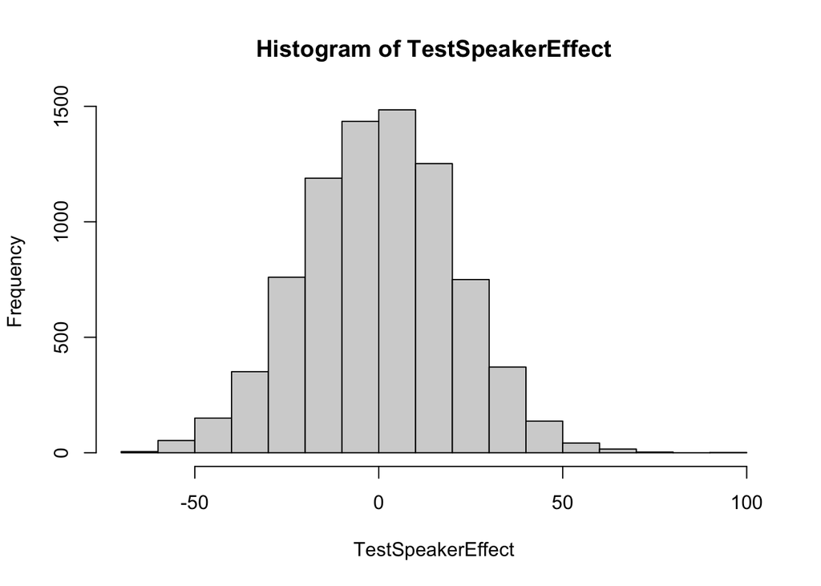

```r
# distribution of the effect of TestSpeaker
TestSpeakerEffect <- colMeans(pp[dat_acq$TestSpeaker=="1",]) - colMeans(pp[dat_acq$TestSpeaker=="2",])
hist(TestSpeakerEffect, breaks = 20)
```

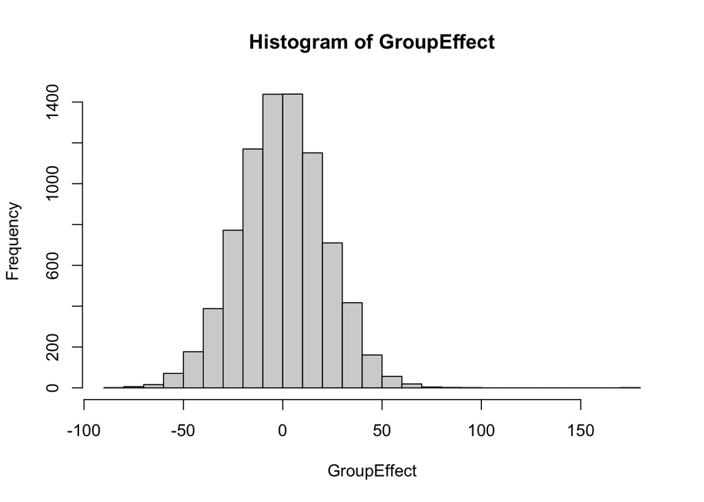

```r
# distribution of the effect of Group
GroupEffect <- colMeans(pp[dat_acq$Group=="fam",]) - colMeans(pp[dat_acq$Group=="unfam",])
hist(GroupEffect, breaks = 20)
```

We don’t get an effect for TestSpeaker nor for Group (which was also not assumed in our priors).

Conclusion: our priors seem to be reasonable.

### Posterior predictive checks

Here, we check whether our model can recover our simulated data, with our proposed priors. Our data were simulated as follows:

- mean = 5
- SD = 15
- effect of Group = 5
- effect of TestSpeaker = 5

We run the model with more iterations (20000) to ensure full convergence:

```r
num_chains <- 4
num_iter <-20000
num_warmup <- num_iter / 2
num_thin <- 1
```

We also set the contrast such that we get equal priors on the different comparisons. This is important for our Bayes Factor analysis later on.

```r
contrasts(dat_acq$TestSpeaker) <- contr.equalprior
contrasts(dat_acq$Group) <- contr.equalprior
contrasts(dat_acq$sleepState) <- contr.equalprior

contrasts(dat_acq$TestSpeaker)
```

```
##         [,1]
## 1 -0.7071068
## 2  0.7071068
```

```r
contrasts(dat_acq$Group)
```

```
##             [,1]
## fam   -0.7071068
## unfam  0.7071068
```

```r
contrasts(dat_acq$sleepState)
```

```
##                   [,1]       [,2]
## activesleep  0.0000000  0.8164966
## awake       -0.7071068 -0.4082483
## quietsleep   0.7071068 -0.4082483
```

Now let’s look at the model:

```r
# postpredcheck_acq_m <- brm(MMR ~ 1 + TestSpeaker * Group +
#                             mumDist +
#                             nrSpeakersDaily +
#                             sleepState +
#                              age +
#                              (1 + TestSpeaker | Subj),
#                            data = dat_acq,
#                            prior = priors,
#                            family = gaussian(),
#                            control = list(
#                              adapt_delta = .99,
#                              max_treedepth = 15
#                            ),
#                            iter = num_iter,
#                            chains = num_chains,
#                            warmup = num_warmup,
#                            thin = num_thin,
#                            cores = num_chains,
#                            seed = project_seed,
#                            file = here("data", "model_output", "04_model_posteriorpredcheck_acq.rds"),
#                            file_refit = "on_change",
#                            save_pars = save_pars(all = TRUE)
# )


postpredcheck_acq_m <- readRDS(here("data", "model_output", "04_model_posteriorpredcheck_acq.rds"))
summary(postpredcheck_acq_m)
```

```
##  Family: gaussian
##   Links: mu = identity; sigma = identity
## Formula: MMR ~ 1 + TestSpeaker * Group + mumDist + nrSpeakersDaily + sleepState + age + (1 + TestSpeaker | Subj)
##    Data: dat_acq (Number of observations: 128)
##   Draws: 4 chains, each with iter = 20000; warmup = 10000; thin = 1;
##          total post-warmup draws = 40000
##
## Group-Level Effects:
## ~Subj (Number of levels: 64)
##                             Estimate Est.Error l-95% CI u-95% CI Rhat Bulk_ESS
## sd(Intercept)                   4.07      2.50     0.20     9.25 1.00     1276
## sd(TestSpeaker1)                5.35      3.41     0.26    12.60 1.00     1221
## cor(Intercept,TestSpeaker1)     0.20      0.50    -0.87     0.96 1.00    12608
##                             Tail_ESS
## sd(Intercept)                    875
## sd(TestSpeaker1)                 703
## cor(Intercept,TestSpeaker1)    17602
##
## Population-Level Effects:
##                     Estimate Est.Error l-95% CI u-95% CI Rhat Bulk_ESS Tail_ESS
## Intercept               4.48      1.23     2.07     6.89 1.00    37160    28922
## TestSpeaker1           -3.34      1.72    -6.72     0.04 1.00    35629    28833
## Group1                 -2.74      1.76    -6.19     0.71 1.00    28586    23603
## mumDist                -0.63      1.24    -3.07     1.80 1.00    29800    29110
## nrSpeakersDaily        -0.22      1.26    -2.69     2.24 1.00    32262    28844
## sleepState1            -3.04      2.20    -7.38     1.25 1.00    27126    24708
## sleepState2             2.97      2.11    -1.16     7.13 1.00    27760    26979
## age                     0.84      1.26    -1.66     3.31 1.00    28227    24856
## TestSpeaker1:Group1     3.60      2.41    -1.17     8.37 1.00    36206    27678
##
## Family Specific Parameters:
##       Estimate Est.Error l-95% CI u-95% CI Rhat Bulk_ESS Tail_ESS
## sigma    12.00      2.02     6.13    14.81 1.00     1046      464
##
## Draws were sampled using sampling(NUTS). For each parameter, Bulk_ESS
## and Tail_ESS are effective sample size measures, and Rhat is the potential
## scale reduction factor on split chains (at convergence, Rhat = 1).
```

There were 50 divergent transitions after warmup. However, the model seems to have converged, since the Rhat and ESS values are good.

We can now check the values the model comes up with for the simulated data: b_Intercept is 4.48 (in the data it was simulated as 5) It retrieves an effect of 3.34 for TestSpeaker It retrieves an effect of 2.74 for Group It also hallucinates some effects for the covariates sigma is estimated at 12.00.

These effects for TestSpeaker and Group seem a bit low, considering our simulated effects of 5. However, this is actually because of our contrast matrix:

```r
contrasts(dat_acq$TestSpeaker)
```

```
##         [,1]
## 1 -0.7071068
## 2  0.7071068
```

This contrast matrix is derived from dividing -1 and 1 (sum coding) by the square root of 2. The standardization ensures that the contrast has a variance of 1, meaning that the different contrasts are independent (orthogonal) of each other in case of multiple contrasts. This makes it easier to compare outcomes across different contexts of measurements. This however also means that the coefficients are not easily interpretable in their original units anymore. So to check whether the model has a more or less sensible estimate for the effects of TestSpeaker and Group, we run the model again, with deviation coding of -0.5 and 0.5. In this case, the coding represents the difference between TestSpeaker1 and TestSpeaker2, and Group-fam and Group-unfam:

```r
contrasts(dat_acq$TestSpeaker) <- matrix(c(-0.5, 0.5), ncol = 1)
contrasts(dat_acq$Group) <- matrix(c(-0.5, 0.5), ncol = 1)
contrasts(dat_acq$sleepState) <- matrix(c(-2/3, 1/3, 1/3,
                                          1/3, -2/3, 1/3),
                                        ncol = 2, byrow = TRUE)

contrasts(dat_acq$TestSpeaker)
```

```
##   [,1]
## 1 -0.5
## 2  0.5
```

```r
contrasts(dat_acq$Group)
```

```
##       [,1]
## fam   -0.5
## unfam  0.5
```

```r
contrasts(dat_acq$sleepState)
```

```
##                   [,1]      [,2]
## activesleep -0.6666667 0.3333333
## awake        0.3333333 0.3333333
## quietsleep  -0.6666667 0.3333333
```

We now run the model again:

```r
# postpredcheck_sumcontrast_acq_m <- brm(MMR ~ 1 + TestSpeaker * Group +
#                              mumDist +
#                              nrSpeakersDaily +
#                              sleepState +
#                              age +
#                              (1 + TestSpeaker | Subj),
#                            data = dat_acq,
#                            prior = priors,
#                            family = gaussian(),
#                            control = list(
#                              adapt_delta = .99,
#                              max_treedepth = 15
#                            ),
#                            iter = num_iter,
#                            chains = num_chains,
#                            warmup = num_warmup,
#                            thin = num_thin,
#                            cores = num_chains,
#                            seed = project_seed,
#                            file = here("data", "model_output", "04_model_posteriorpredcheck_sumcontrast_acq.rds"),
#                            file_refit = "on_change",
#                            save_pars = save_pars(all = TRUE)
# )

postpredcheck_sumcontrast_acq_m <- readRDS(here("data", "model_output", "04_model_posteriorpredcheck_sumcontrast_acq.rds"))
summary(postpredcheck_sumcontrast_acq_m)
```

```
##  Family: gaussian
##   Links: mu = identity; sigma = identity
## Formula: MMR ~ 1 + TestSpeaker * Group + mumDist + nrSpeakersDaily + sleepState + age + (1 + TestSpeaker | Subj)
##    Data: dat_acq (Number of observations: 128)
##   Draws: 4 chains, each with iter = 20000; warmup = 10000; thin = 1;
##          total post-warmup draws = 40000
##
## Group-Level Effects:
## ~Subj (Number of levels: 64)
##                             Estimate Est.Error l-95% CI u-95% CI Rhat Bulk_ESS
## sd(Intercept)                   3.33      2.28     0.15     8.48 1.00     2067
## sd(TestSpeaker1)                7.69      4.78     0.42    17.79 1.00     2065
## cor(Intercept,TestSpeaker1)     0.11      0.52    -0.90     0.95 1.00    15860
##                             Tail_ESS
## sd(Intercept)                   1164
## sd(TestSpeaker1)                1206
## cor(Intercept,TestSpeaker1)    19526
##
## Population-Level Effects:
##                     Estimate Est.Error l-95% CI u-95% CI Rhat Bulk_ESS Tail_ESS
## Intercept               5.01      6.84    -8.38    18.38 1.00    66223    27147
## TestSpeaker1           -4.70      2.50    -9.54     0.25 1.00    44362    28775
## Group1                 -4.66      2.44    -9.39     0.13 1.00    44673    27692
## mumDist                -0.25      1.24    -2.69     2.19 1.00    44969    29905
## nrSpeakersDaily        -0.32      1.24    -2.73     2.10 1.00    46494    30112
## sleepState1             1.19      2.67    -4.05     6.49 1.00    49765    28359
## sleepState2             0.00     20.01   -38.90    39.11 1.00    68082    27358
## age                     1.04      1.23    -1.38     3.47 1.00    43504    27986
## TestSpeaker1:Group1     6.86      4.85    -2.73    16.32 1.00    44020    28570
##
## Family Specific Parameters:
##       Estimate Est.Error l-95% CI u-95% CI Rhat Bulk_ESS Tail_ESS
## sigma    12.40      1.84     7.00    15.02 1.00     1787      804
##
## Draws were sampled using sampling(NUTS). For each parameter, Bulk_ESS
## and Tail_ESS are effective sample size measures, and Rhat is the potential
## scale reduction factor on split chains (at convergence, Rhat = 1).
```

Here we see that the model is actually perfectly able to retrieve the data: b_Intercept is 5.01 (in the data it was simulated as 5) It retrieves an effect of 4.70 for TestSpeaker (in the data it was simulated as 5) It retrieves an effect of 4.66 for Group (in the data it was simulated as 5) It also hallucinates some minor effects for the covariates sigma is estimated at 12.40 (simulated as 15)

This model has 33 divergent transitions. However, Rhat and the ESS values are good.

```r
# set contrasts back
contrasts(dat_acq$TestSpeaker) <- contr.equalprior
contrasts(dat_acq$Group) <- contr.equalprior
contrasts(dat_acq$sleepState) <- contr.equalprior
```

Now we continue checking our model with the model that uses the coding we will use in the final analysis:

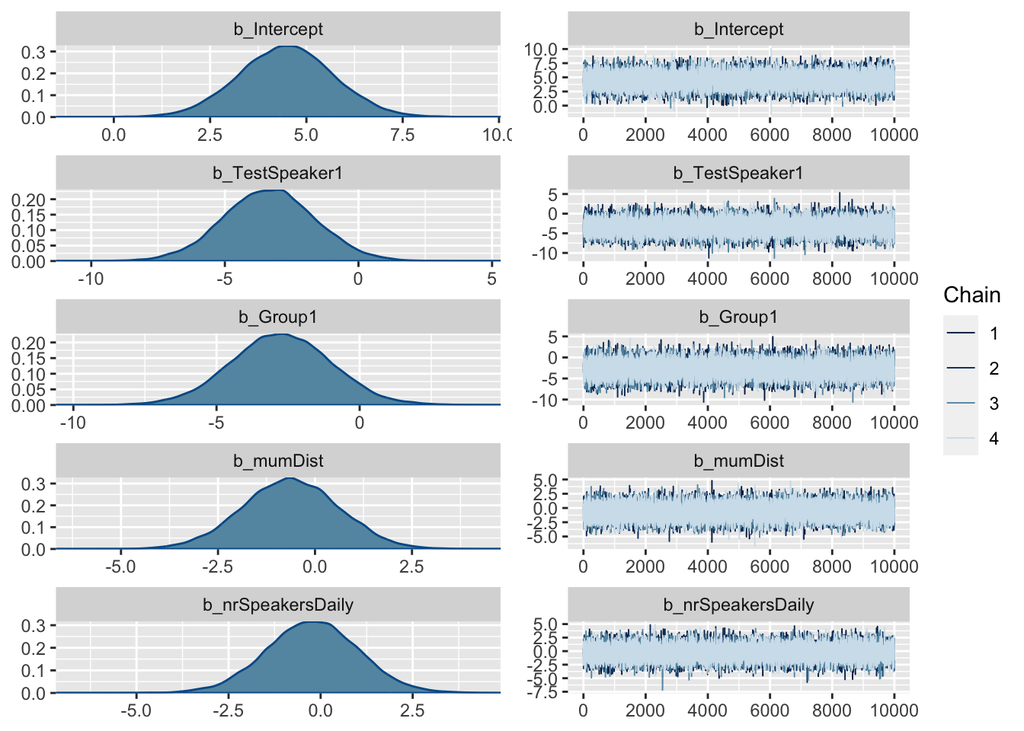

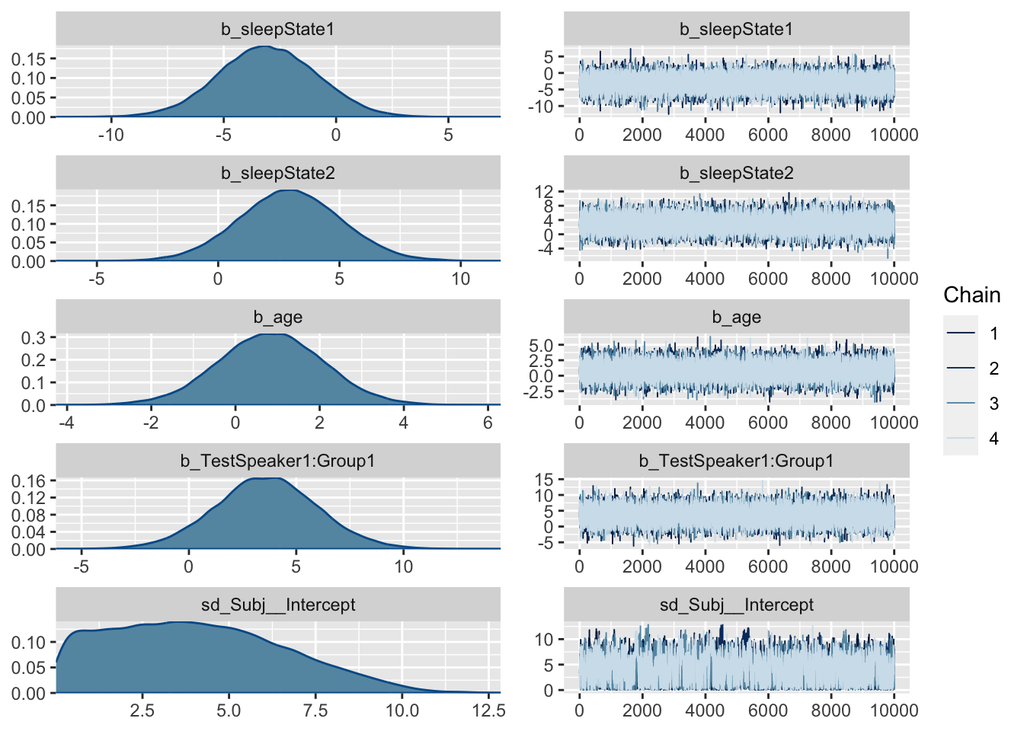

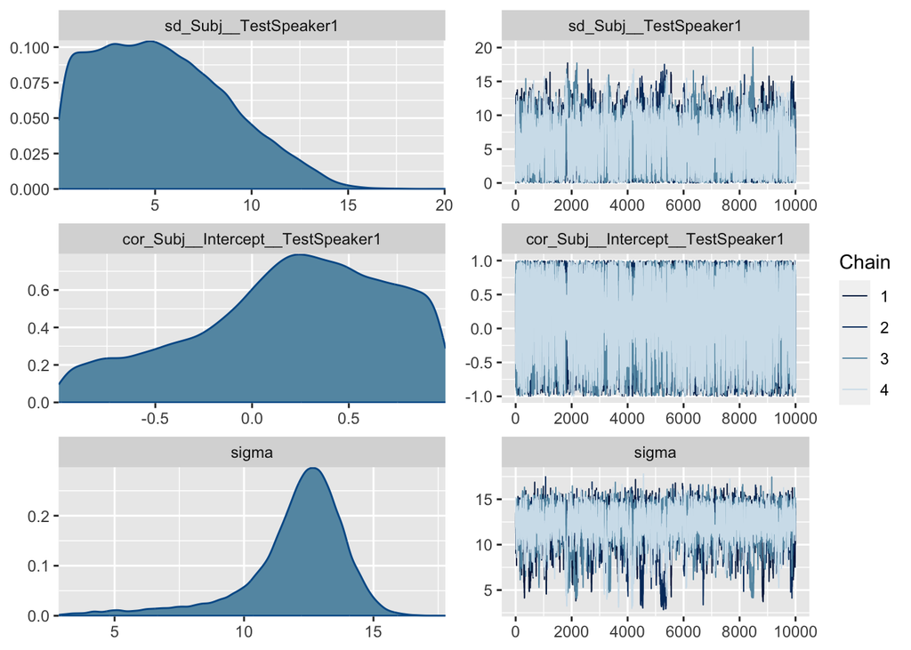

```r
plot(postpredcheck_acq_m) # check traces and posterior distributions
```

Here we see that the traces all look like nice hairy caterpillars, meaning that the chains have mixed. The posterior distribitions also look good (and we checked the estimates in the summary already)

Now we check whether the model is able to retrieve the underlying data. y is the observed data, so the data that we inputted, and y’ is the simulated data from the posterior predictive distribution.

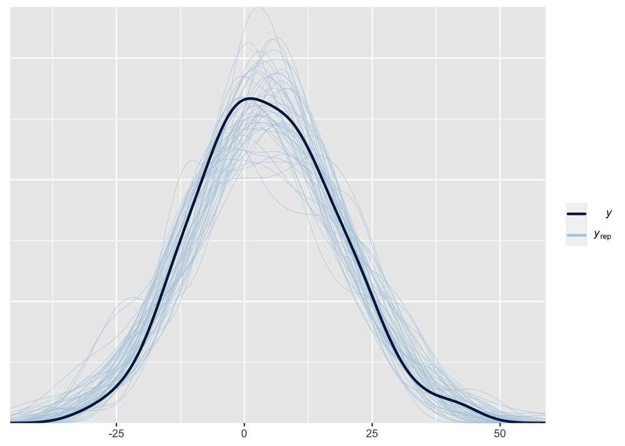

```r
pp_check(postpredcheck_acq_m, ndraws=50)
```

This looks good: the data overlap.

It thus seems as if both our priors and our model are adequate for our simulated data. We assume that this will also be the case for our experimental data.

### Sensitivity analysis

To check how dependent the model’s outcome is on the priors, we perform a sensitivity analysis. We will check the estimates of our model with our proposed priors `normal(3.5,20)`, and three alternative priors:

- `normal(0,20)`: the same SD but the a mean of zero
- `normal(0,30)`: weakly informative, because of the large SD
- `normal(0,50)`: uninformative, not really biologically plausible anymore

```r
priors_orig <-
  c(set_prior("normal(3.5, 20)",
              class = "Intercept"),
    set_prior("normal(0, 20)",
              class = "b"),
    set_prior("normal(0, 20)",
              class = "sigma"))

priors1 <-
  c(set_prior("normal(0, 20)",  # changing the mean of the intercept to 0
              class = "Intercept"),
    set_prior("normal(0, 20)",
              class = "b"),
    set_prior("normal(0, 20)",
              class = "sigma"))
priors2 <-
  c(set_prior("normal(0, 30)",
              class = "Intercept"),
    set_prior("normal(0, 30)",
              class = "b"), # weakly informative prior on intercept & slopes: this is still biologically plausible
    set_prior("normal(0, 30)",
              class = "sigma"))

priors3 <-
  c(set_prior("normal(0, 50)",
              class = "Intercept"),
    set_prior("normal(0, 50)",
              class = "b"), # uninformative prior on intercept & slopes: this is not biologically plausible
    set_prior("normal(0, 50)",
              class = "sigma"))
```

Let’s plot these different priors:

[figure not shown]

We ran the model of the posterior checks with these three alternative priors, such that we can compare the different estimates:

```r
m_sens_orig <- readRDS(here("data", "model_output", "04_model_posteriorpredcheck_acq.rds"))
m_sens_1 <- readRDS(here("data", "model_output", "05_model_sensitivity_altern1_acq.rds"))
m_sens_2 <- readRDS(here("data", "model_output", "05_model_sensitivity_altern2_acq.rds"))
m_sens_3 <- readRDS(here("data", "model_output", "05_model_sensitivity_altern3_acq.rds"))

posterior_summary(m_sens_orig, variable=c("b_Intercept","b_TestSpeaker1", "b_Group1", "sigma"))
```

```
##                 Estimate Est.Error      Q2.5       Q97.5
## b_Intercept     4.476701  1.233475  2.066365  6.88690418
## b_TestSpeaker1 -3.337445  1.721101 -6.719559  0.04269745
## b_Group1       -2.743106  1.755626 -6.192229  0.70720741
## sigma          11.997815  2.022676  6.131648 14.80679606
```

```r
posterior_summary(m_sens_1, variable=c("b_Intercept","b_TestSpeaker1", "b_Group1", "sigma"))
```

```
##                 Estimate Est.Error      Q2.5        Q97.5
## b_Intercept     4.477612  1.239896  2.010546  6.910493444
## b_TestSpeaker1 -3.365434  1.723943 -6.779599  0.006534903
## b_Group1       -2.779273  1.764532 -6.243833  0.685935025
## sigma          11.817000  2.264657  4.938525 14.730494266
```

```r
posterior_summary(m_sens_2, variable=c("b_Intercept","b_TestSpeaker1", "b_Group1", "sigma"))
```

```
##                 Estimate Est.Error      Q2.5       Q97.5
## b_Intercept     4.482134  1.223728  2.099806  6.87142283
## b_TestSpeaker1 -3.373665  1.731923 -6.772624  0.03514507
## b_Group1       -2.768331  1.767483 -6.220352  0.70771408
## sigma          11.870823  2.210842  5.270393 14.81278623
```

```r
posterior_summary(m_sens_3, variable=c("b_Intercept","b_TestSpeaker1", "b_Group1", "sigma"))
```

```
##                 Estimate Est.Error      Q2.5       Q97.5
## b_Intercept     4.475724  1.245108  2.007527  6.92544715
## b_TestSpeaker1 -3.360625  1.713918 -6.720793  0.01924516
## b_Group1       -2.772055  1.772809 -6.237518  0.68847601
## sigma          11.923507  2.207247  5.432894 14.78848226
```

We can now also plot different estimates for the different priors:

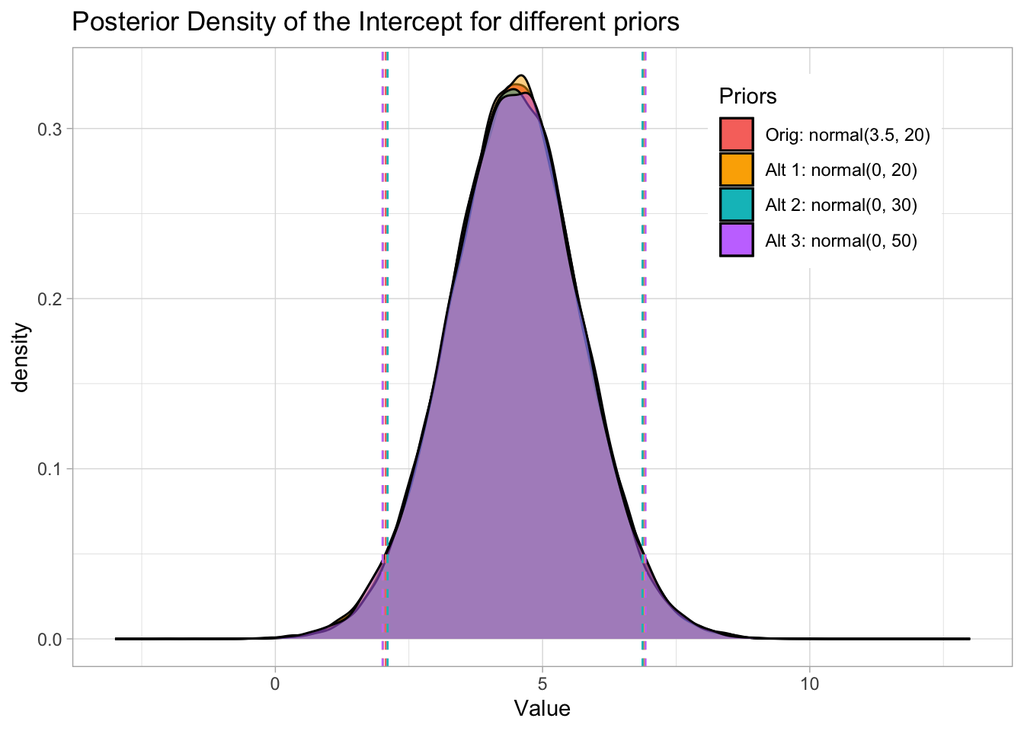

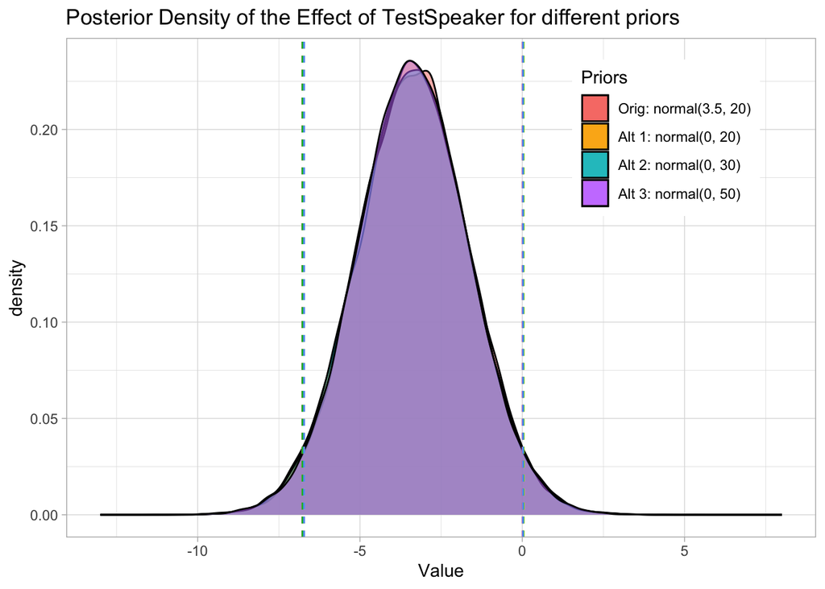

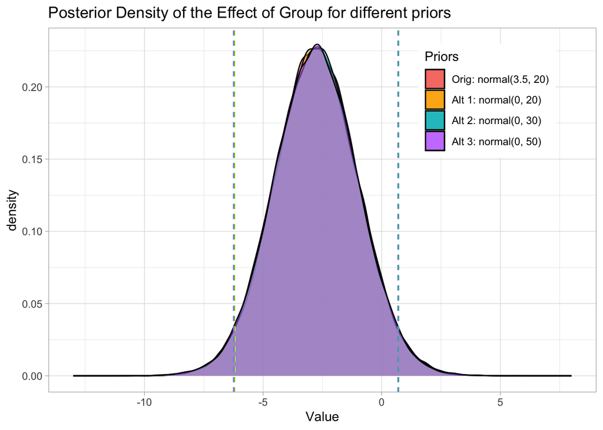

As we can see from the (plotted) estimates, the different priors barely have any effect on the estimates of the model. This means that our model is not overly sensitive to the priors.

We will run the same sensitivity analysis for our model with our experimental data.

### Parameter estimation experimental data

For the experimental data, we will use the following code for parameter estimation, assuming the same data structure, and the data called dat_exp_acq

```
# scaling the continuous predictors:
dat_exp_acq$mumDist<- scale(dat_exp_acq$mumDist)
dat_exp_acq$age <- scale(dat_exp_acq$age)
dat_exp_acq$nrSpeakersDaily <- scale(dat_exp_acq$nrSpeakersDaily)

# Setting orthogonal contrasts, such that the priors for the different contrasts we compare
contrasts(dat_acq$TestSpeaker) <- contr.equalprior
contrasts(dat_acq$Group) <- contr.equalprior
contrasts(dat_acq$sleepState) <- contr.equalprior

# Setting up the samping:
num_chains <- 4 # number of chains = number of processor cores
num_iter <- 40000 # number of samples per chain: because I use Savage-Dickey for hypothesis testing, so we need a LOT of samples
num_warmup <- num_iter / 2 # number of warm-up samples per chain
num_thin <- 1 # thinning: extract one out of x samples per chain

# Running the model
model_acq <- brm(MMR ~ 1 + TestSpeaker * Group +
                   mumDist +
                   nrSpeakersDaily +
                   sleepState +
                   age +
                   (1 + TestSpeaker | Subj),
                 data = dat_acq,
                 prior = priors,
                 family = gaussian(),
                 control = list(
                   adapt_delta = .99,
                   max_treedepth = 15
                 ),
                 iter = num_iter,
                 chains = num_chains,
                 warmup = num_warmup,
                 thin = num_thin,
                 cores = num_chains,
                 seed = project_seed,
                 file = here("data", "model_output", "04_model_posteriorpredcheck_acq.rds"),
                 file_refit = "on_change",
                 save_pars = save_pars(all = TRUE)
)
```